# Project 1 - Data Story

```r
print(frequencies)
```

```
##
##        Beauvoir           Plato     Malebranche       Aristotle       Nietzsche
##            1467            1171             550             531             495
##         Spinoza            Hume  Wollstonecraft         Deleuze         Leibniz
##             295             244             221             122              81
##        Foucault           Hegel            Kant   Merleau-Ponty          Fichte
##              74              71              69              66              45
##           Locke           Lewis         Russell Marcus Aurelius            Marx
##              44              37              37              35              34
##           Smith          Kripke           Davis         Derrida       Heidegger
##              27              23              15              15              13
##         Husserl           Quine           Moore        Berkeley    Wittgenstein
##               7               6               5               4               3
##       Descartes       Epictetus          Keynes           Lenin          Popper
##               1               1               1               1               1
```

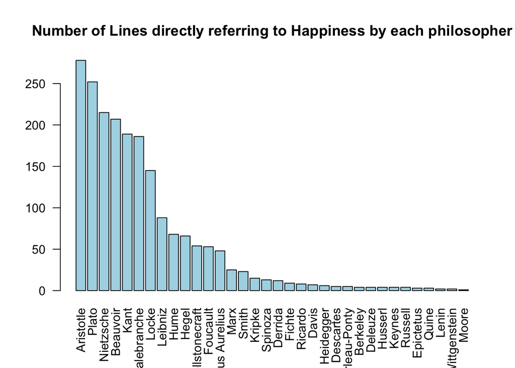

```r
frequencies = HappinessData %>%
  count(author)

frequencies = sort(table(HappinessData$author), T)

barplot(frequencies,las=2,col='lightblue', main ="Number of Lines directly referring to Happiness by each philosopher")
```

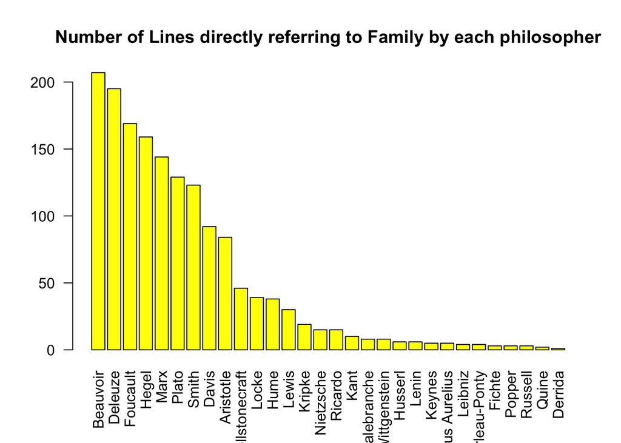

```r
frequencies = FamilyData %>%
  count(author)

frequencies = sort(table(FamilyData$author), T)

barplot(frequencies,las=2,col='yellow', main ="Number of Lines directly referring to Family by each philosopher")
```

```r
sample(LoveData$sentence_str,3)
```

```
## [1] "Let them merit love, and they will obtain it, though they may never be told that: The power of a fine woman over the hearts of men, of men of the finest parts, is even beyond what she conceives."
## [2] "The very reverse may be said of love."
## [3] "That's also how it is with love."
```

```r
sample(HappinessData$sentence_str,3)
```

```
## [1] "I am speaking here of the joy that Adam was able to feel as a necessary consequence of the perception of his happiness in being united to God."
## [2] "I earnestly wish to point out in what true dignity and human happiness consists I wish to persuade women to endeavour to acquire strength, both of mind and body, and to convince them, that the soft phrases, susceptibility of heart, delicacy of sentiment, and refinement of taste, are almost s…
## [3] "But I cannot hope to bring this good about except through the harmony of my will with that of a holy and benign originator of the world; and although the concept of the highest good, as that of a whole in which the greatest happiness is presented as linked in the most exact proportion with t…
```

```r
sample(FamilyData$sentence_str,3)
```

```
## [1] "Thus far at least seems certain, that, in order to bring up a family, the labour of the husband and wife together must, even in the lowest species of common labour, be able to earn something more than what is precisely necessary for their own maintenance; but in what proportion, whether in t…
## [2] "A so called moralperson, such as a society, community, or family, however concrete"
## [3] "Indi rect discourse, in the standard form 'savs that; is the head of a family which includes also 'believes that: 'doubts that,' 'is surprised that,' 'wishes that,' 'strives that,' and the like."
```

Which philosophers write the most on these topics: love, family, and happiness, proportionally to how much they wrote in the whole dataset? Let’s explore this with a graph, but using percentages of the sentences that the philosophers dedicated to each topic. If we use these percentage filters, we uncover that although Beauvoir still comments the most proportionally on Love, Marcus Aurelius and Wollstonecraft lead the philosophers in referencing happiness the most, and Davis, by far, represents family the most. These are very important observations for answering the question of which philosophers talk about which subjects and how often each subject is being referred to in each philosopher’s work.

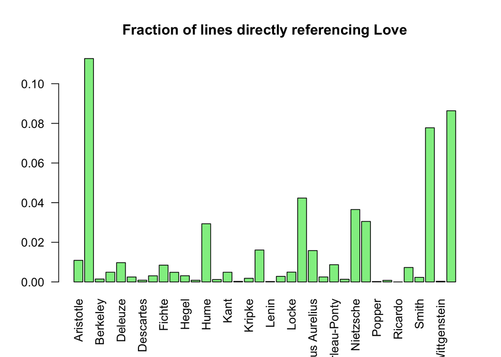

```r
library(dplyr)
library(ggplot2)

#storing percentages based on lines for love, happiness, or family and total lines

freq = data %>%
  count(author)
Lfreq = LoveData %>%
  count(author)
Hfreq = HappinessData %>%
  count(author)
Ffreq = FamilyData %>%
  count(author)
# print(freq$n)
# print(Lfreq$n)
# print(Hfreq$n)
# print(Ffreq$n)


Love_percentages = c(531/48779, 1467/13017,    4/2734,   15/3059,  122/12540,   15/5999,    1/1132,    1/323 ,  45/5308  , 74/15240   ,71/22700 , 13/15239, 244/8312 ,   7/5742 ,  69/14128 ,   1/3411  , 23/12479 , 81/5027,   1/4469 ,  37/13120,   44/8885  ,550/12997 ,  35/2212 ,  34/13489  , 66/7592 ,   5/3668 , 495/13548, 1171/38366  ,  1/4678 ,  6/7373,  0/3090 ,  37/5073 ,  27/11693 , 295/3793 ,   3/9034  ,221/2559)

Happiness_percentages = c(278/48779, 207/13017,    4/2734,   7/3059,  4/12540,   12/5999,    5/1132,    3/323 ,  9/5308  , 53/15240   ,66/22700 , 6/15239, 68/8312 ,   4/5742 ,  189/14128 ,   4/3411  , 15/12479 , 88/5027,   2/4469 ,  0/13120,   145/8885  ,186/12997 ,  48/2212 ,  25/13489  , 5/7592 ,   1/3668 , 215/13548, 252/38366  ,  0/4678 ,  3/7373,  8/3090 ,  4/5073 ,  23/11693 , 13/3793 ,   2/9034  ,54/2559)

Family_percentages = c(84/48779, 207/13017,    0/2734,   92/3059,  195/12540,   1/5999,    0/1132,    0/323 ,  3/5308  , 169/15240   ,159/22700 , 0/15239, 38/8312 ,   6/5742 ,  10/14128 ,   5/3411  , 19/12479 , 4/5027,   6/4469 ,  30/13120,   39/8885  ,8/12997 ,  5/2212 ,  144/13489  , 4/7592 ,   0/3668 , 15/13548, 129/38366  ,  3/4678 ,  2/7373,  15/3090 ,  3/5073 ,  123/11693 , 0/3793 ,   8/9034  ,46/2559)

freq$n = Love_percentages

barplot(freq$n,names.arg = freq$author,las=2, col = 'lightgreen',main = "Fraction of lines directly referencing Love")
```

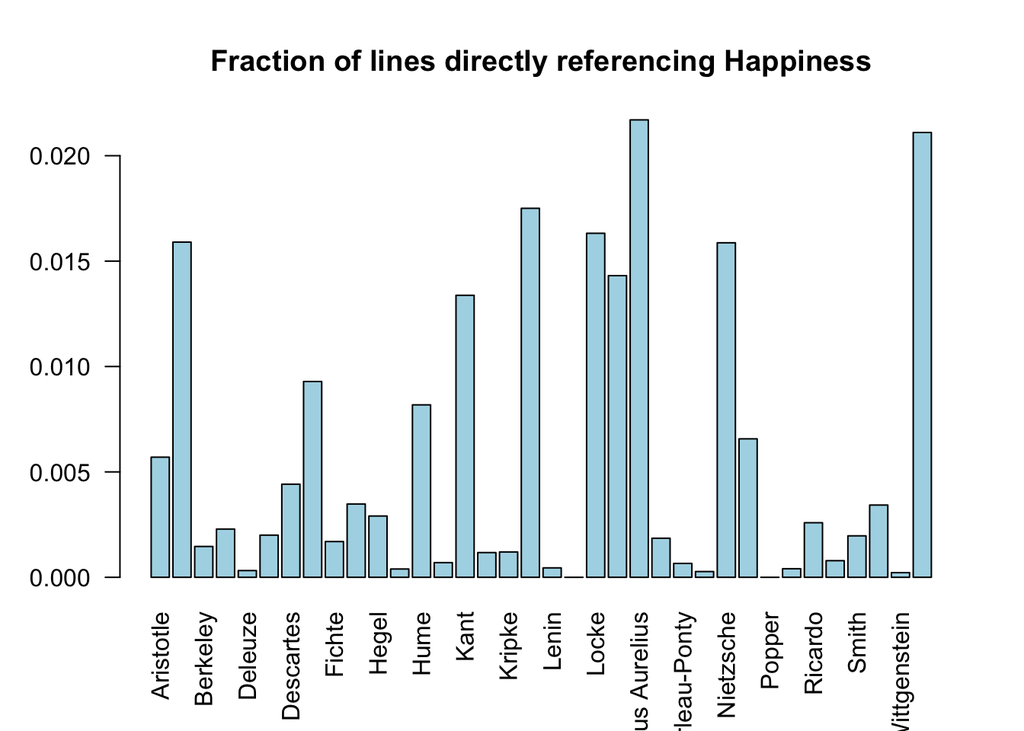

```r
freq$n = Happiness_percentages

barplot(freq$n,names.arg = freq$author,las=2, col = 'lightblue',main = "Fraction of lines directly referencing Happiness")
```

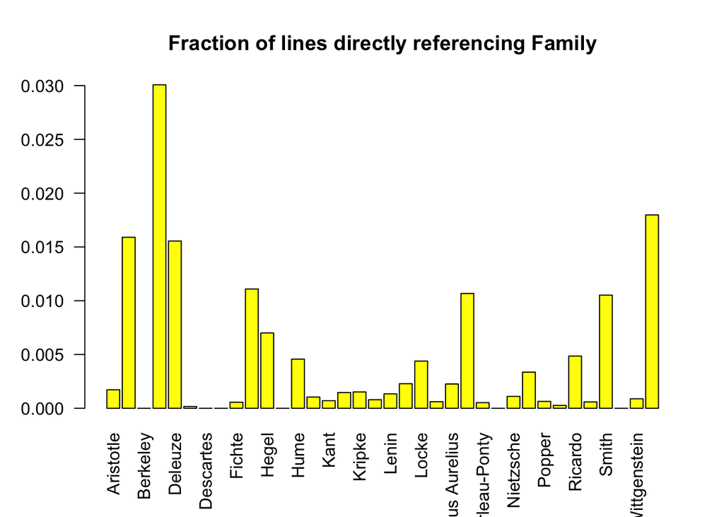

```r
freq$n = Family_percentages

barplot(freq$n,names.arg = freq$author,las=2, col = 'yellow',main = "Fraction of lines directly referencing Family")
```

Let’s first explore these partitioned data sets via Wordclouds. WordClouds are a great visualization tool to see which words are most prevelant in the selected sentences we picked with each section. This data story removed stopwords and the words that are filtered for so that the most important words are displayed.

```r
library("tm")
```

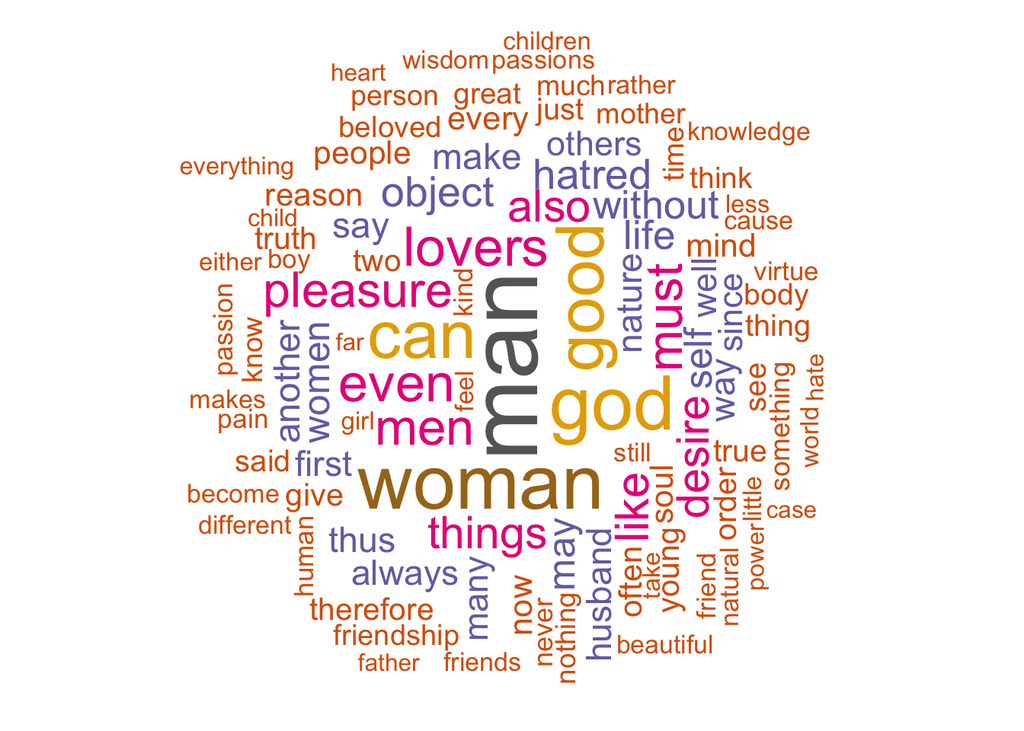

```r
library("SnowballC")
library("wordcloud")
library("RColorBrewer")
library(dplyr)
library(stringr)

# creating corpus for the word cloud from LoveData


WordCloudL = subset(LoveData,select = c(tokenized_txt))


dataDS.Corpus<-Corpus(VectorSource(WordCloudL))


#Data cleaning and wrangling:
dataDS.Clean<-tm_map(dataDS.Corpus, PlainTextDocument)
dataDS.Clean<-tm_map(dataDS.Clean,removeWords,stopwords("english"))
dataDS.Clean = tm_map(dataDS.Clean,removeWords,c("love","lover","loves","loved","one","will"))
dataDS.Clean<-tm_map(dataDS.Clean,removePunctuation)

wordcloud(words = dataDS.Clean, min.freq = 1,
          max.words=100, random.order=FALSE, rot.per=0.35,
          colors=brewer.pal(8, "Dark2"))
```

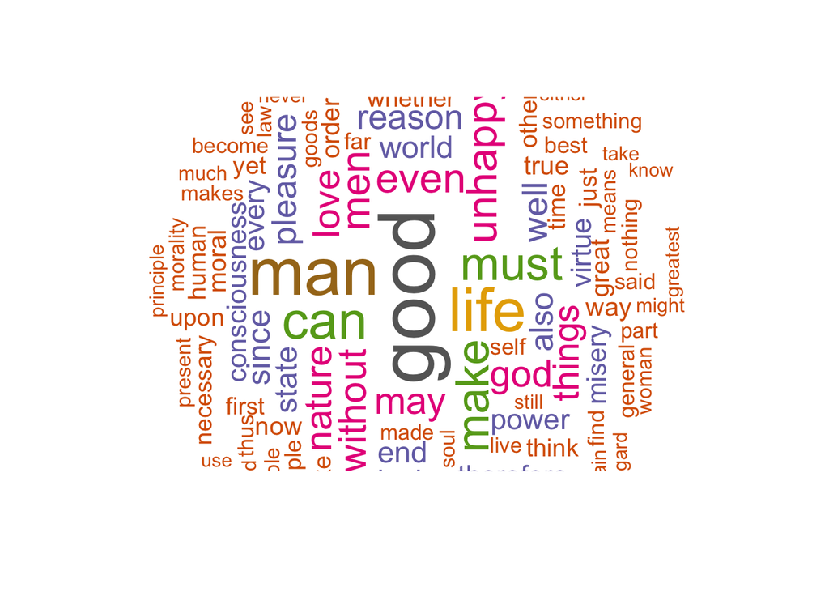

```r
# creating corpus for the word cloud from HappinessData

WordCloudH = subset(HappinessData,select = c(tokenized_txt))


dataDS.Corpus<-Corpus(VectorSource(WordCloudH))


#Data cleaning and wrangling:
dataDS.Clean<-tm_map(dataDS.Corpus, PlainTextDocument)
dataDS.Clean<-tm_map(dataDS.Clean,removeWords,stopwords("english"))
dataDS.Clean = tm_map(dataDS.Clean,removeWords,c("happy","happiness","one","will"))
dataDS.Clean<-tm_map(dataDS.Clean,removePunctuation)

wordcloud(words = dataDS.Clean, min.freq = 1,
          max.words=100, random.order=FALSE, rot.per=0.35,
          colors=brewer.pal(8, "Dark2"))
```

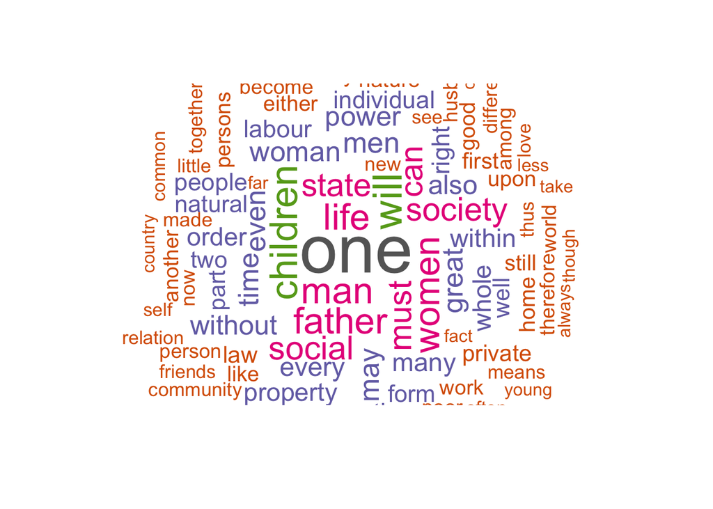

```r
# creating corpus for the word cloud from FamilyData

WordCloudF = subset(FamilyData,select = c(tokenized_txt))


dataDS.Corpus<-Corpus(VectorSource(WordCloudF))


#Data cleaning and wrangling:
dataDS.Clean<-tm_map(dataDS.Corpus, PlainTextDocument)
dataDS.Clean<-tm_map(dataDS.Clean,removeWords,stopwords("english"))
dataDS.Clean = tm_map(dataDS.Clean,removeWords,c("family","families"))
dataDS.Clean<-tm_map(dataDS.Clean,removePunctuation)

wordcloud(words = dataDS.Clean, min.freq = 1,
          max.words=100, random.order=FALSE, rot.per=0.35,
          colors=brewer.pal(8, "Dark2"))
```

```r
# library(devtools)
# install_github("mukul13/rword2vec")
#
library(word2vec)

x = data$sentence_str

model <- word2vec(x = x, type = "cbow", dim = 15, iter = 20)

embedding <- as.matrix(model)
lookslike <- predict(model, c("love", "family","happiness"), type = "nearest", top_n = 5)
lookslike
```

```
## $love
##   term1     term2 similarity rank
## 1  love  kindness  0.9664954    1
## 2  love   remorse  0.9586401    2
## 3  love aloofness  0.9517159    3
## 4  love    intere  0.9509998    4
## 5  love  aversion  0.9505420    5
##
## $family
##    term1     term2 similarity rank
## 1 family     tribe  0.9620816    1
## 2 family      clan  0.9393880    2
## 3 family      army  0.9359204    3
## 4 family    nation  0.9333805    4
## 5 family hisdomain  0.9333225    5
##
## $happiness
##       term1        term2 similarity rank
## 1 happiness        pride  0.9668409    1
## 2 happiness satisfaction  0.9634089    2
## 3 happiness   wickedness  0.9580528    3
## 4 happiness     appetite  0.9562003    4
## 5 happiness         evil  0.9557843    5
```

```r
#Looking at the closest words from the love wordcloud
lookslike <- predict(model, c("woman","man","god","good"), type = "nearest", top_n = 5)
lookslike
```

```
## $woman
##   term1     term2 similarity rank
## 1 woman courtesan  0.9639874    1
## 2 woman      lise  0.9530420    2
## 3 woman      girl  0.9464751    3
## 4 woman   Overman  0.9457062    4
## 5 woman sacrament  0.9422463    5
##
## $man
##   term1  term2 similarity rank
## 1   man    god  0.9648470    1
## 2   man person  0.9645652    2
## 3   man  thief  0.9470394    3
## 4   man  lover  0.9438072    4
## 5   man  woman  0.9408262    5
##
## $god
##   term1   term2 similarity rank
## 1   god   thief  0.9773050    1
## 2   god brother  0.9729586    2
## 3   god goddess  0.9710363    3
## 4   god     son  0.9695668    4
## 5   god     man  0.9648470    5
##
## $good
##   term1     term2 similarity rank
## 1  good  virtuous  0.9584814    1
## 2  good injustice  0.9502372    2
## 3  good    unjust  0.9490260    3
## 4  good       bad  0.9464683    4
## 5  good  shameful  0.9318521    5
```

```r
#Looking at the closest words from the happiness wordcloud
lookslike <- predict(model, c("man","life","good","must"), type = "nearest", top_n = 5)
lookslike
```

```
## $man
##   term1  term2 similarity rank
## 1   man    god  0.9648470    1
## 2   man person  0.9645652    2
## 3   man  thief  0.9470394    3
## 4   man  lover  0.9438072    4
## 5   man  woman  0.9408262    5
##
## $life
##   term1       term2 similarity rank
## 1  life    intrigue  0.9694669    1
## 2  life destruction  0.9571703    2
## 3  life    activity  0.9495936    3
## 4  life    humanity  0.9447142    4
## 5  life       habit  0.9431252    5
##
## $good
##   term1     term2 similarity rank
## 1  good  virtuous  0.9584814    1
## 2  good injustice  0.9502372    2
## 3  good    unjust  0.9490260    3
## 4  good       bad  0.9464683    4
## 5  good  shameful  0.9318521    5
##
## $must
##   term1  term2 similarity rank
## 1  must cannot  0.9916195    1
## 2  must    can  0.9899467    2
## 3  must    may  0.9877151    3
## 4  must  could  0.9874004    4
## 5  must   will  0.9863044    5
```

```r
#Looking at the closest words from the fanily wordcloud
lookslike <- predict(model, c("women","children","father","social"), type = "nearest", top_n = 5)
lookslike
```

```
## $women
##   term1      term2 similarity rank
## 1 women    tyrants  0.9652398    1
## 2 women  actresses  0.9646336    2
## 3 women      girls  0.9545412    3
## 4 women courtesans  0.9526733    4
## 5 women    doctors  0.9526026    5
##
## $children
##      term1       term2 similarity rank
## 1 children   daughters  0.9720064    1
## 2 children      slaves  0.9675998    2
## 3 children competitors  0.9568332    3
## 4 children    husbands  0.9534322    4
## 5 children    soldiers  0.9522310    5
##
## $father
##    term1    term2 similarity rank
## 1 father daughter  0.9903272    1
## 2 father     wife  0.9891904    2
## 3 father  husband  0.9889883    3
## 4 father  brother  0.9843411    4
## 5 father      son  0.9757318    5
##
## $social
##    term1       term2 similarity rank
## 1 social    cultural  0.9602797    1
## 2 social  repressive  0.9506761    2
## 3 social patriarchal  0.9335064    3
## 4 social centralized  0.9233228    4
## 5 social       local  0.9207898    5
```

Conclusion